# **Multivariate Linear Regression**

Giorgi Nikolaishvili EC 320: Introduction to Econometrics University of Oregon

Spring 2022

## Recap

In the previous two (recorded) labs, we learned the following:

- Estimating simple linear regression models (using `lm()`)
- Presenting model estimates (using `modelsummary()` from the `modelsummary` package)
- Testing hypotheses regarding the possible true values of model coefficients (using `summary()` to retrieve model estimates, and `qt()` to generate critical $t$-statistics)

In today’s lab we will apply the same exact functions as above to **multivariate** linear regression modeling – in other words, we will now consider more than just one regressor (independent variable).

## Intuition

Let’s begin by briefly and non-rigorously (and certainly not comprehensively) discussing why multivariate regression model specification is oftentimes necessary.

Suppose we are interested in learning the effect of some variable $X$ on $Y$.

Why can’t we just estimate a simple linear regression model of the form $Y = \beta_0 + \beta_1 X + \varepsilon$?

Well, sometimes we can! But this is very rare, and difficult to justify.

Oftentimes a simple regression will yield “inaccurate” results with regards to the *true* effect of $X$ on $Y$, because of **OMITTED VARIABLE BIAS**.

Omitted variable bias is caused by the existence of a third variable $Z$ that also affects $Y$ and is correlated with $X$. In such a case, we must account for the variation in $Z$ by including it in our model:
$$Y = \beta_0 + \beta_1 X +
\beta_2 Z + \upsilon$$

Why? **Because if we do not account for the variation in $Y$ caused by $Z$, then the least squares (LS) estimator will attribute said variation to $X$ and bias our estimate of $\beta_1$:**

- If $Corr(X,Z) > 0$ and $\beta_2 > 0$ and we do not include $Z$ as a regressor in our model, then our estimate of $\beta_1$ will likely be larger than its true value (**positively biased**).
- If $Corr(X,Z) > 0$ and $\beta_2 < 0$ and we do not include $Z$ as a regressor in our model, then our estimate of $\beta_1$ will likely be smaller than its true value (**negatively biased**).
- If $Corr(X,Z) < 0$ and $\beta_2 > 0$ and we do not include $Z$ as a regressor in our model, then our estimate of $\beta_1$ will likely be smaller than its true value (**negatively biased**).
- If $Corr(X,Z) < 0$ and $\beta_2 < 0$ and we do not include $Z$ as a regressor in our model, then our estimate of $\beta_1$ will likely be larger than its true value (**positively biased**).

If you are still unconvinced that excluding $Z$ from our model of $Y$ will bias our estimate of $\beta_1$, consider that if the following is the *true* model of $Y$:
$$Y = \beta_0 + \beta_1 X + \beta_2 Z +
\upsilon$$
and instead we estimate
$$Y
= \beta_0 + \beta_1 X + \varepsilon$$
then it must be true that
$$\varepsilon = \beta_2 Z + \upsilon$$
which implies that $Corr(X,\varepsilon) \neq 0$, which violates one of the main assumptions for the linear unbiasedness of the LS estimator! The likely direction of this bias is a product of the covariance/correlation between $X$ and $Z$.

## Example

Suppose we would like to estimate the effect of education on wage.

Would it be wise to estimate the below regression model?

$$\text{wage} = \beta_0 + \beta_1
\text{education} + \varepsilon$$

**Probably not – there are plenty of variables other than education that affect wages while being correlated with education!**

Can you think of any?

- Ability
- Years of experience (?)
- Connections/family/background (?)

So the model we should ideally be estimating would look something like the following:

$$\text{wage} = \beta_0 + \beta_1
\text{education} + \beta_2 \text{ability} + \varepsilon$$

Had we estimated the model without controlling for ability, in which direction would $\beta_1$ likely be biased?

Consider that, intuitively, the following is probably true: - $Corr(\text{education},\text{ability}) > 0$ - $\beta_2 > 0$

Then we know $\beta_1$ must be biased *positively* / *upward*.

## Another Example

In this next example, we will conduct an empirical analysis involving the concepts we have touched on so far.

Load the following packages:

- `tidyverse` – this will be used for data manipulation, plotting, etc.
- `modelsummary` – gives us access to the `modelsummary()` function for presenting regression outputs
- `AER` – source of data

```r
library(pacman)
p_load(tidyverse, modelsummary, AER);
```

We will be working with the `CASchools` dataset that lives within the `AER` package.

```r
data(CASchools) # special way to load dataset from `AER`
head(CASchools)
```

```
##   district                          school  county grades students teachers
## 1    75119              Sunol Glen Unified Alameda  KK-08      195    10.90
## 2    61499            Manzanita Elementary   Butte  KK-08      240    11.15
## 3    61549     Thermalito Union Elementary   Butte  KK-08     1550    82.90
## 4    61457 Golden Feather Union Elementary   Butte  KK-08      243    14.00
## 5    61523        Palermo Union Elementary   Butte  KK-08     1335    71.50
## 6    62042         Burrel Union Elementary  Fresno  KK-08      137     6.40
##   calworks   lunch computer expenditure    income   english  read  math
## 1   0.5102  2.0408       67    6384.911 22.690001  0.000000 691.6 690.0
## 2  15.4167 47.9167      101    5099.381  9.824000  4.583333 660.5 661.9
## 3  55.0323 76.3226      169    5501.955  8.978000 30.000002 636.3 650.9
## 4  36.4754 77.0492       85    7101.831  8.978000  0.000000 651.9 643.5
## 5  33.1086 78.4270      171    5235.988  9.080333 13.857677 641.8 639.9
## 6  12.3188 86.9565       25    5580.147 10.415000 12.408759 605.7 605.4
```

This dataset contains 14 variables – we will only be using the following:

- `students`: # of students in a given school
- `teachers`: # of teachers in a given school
- `read`: average SAT Reading score in a given scool
- `math`: average SAT Math score in a given school
- `english`: share of English learning students (non-native speakers) in a given school

```r
data_df <- CASchools %>%
            select(students, teachers, read, math, english)
```

Suppose we would like to **estimate the effect of classroom size on test scores.**

First, we need to construct a measure of classroom size, and a measure of test scores using the given data.

```r
data_df <- data_df %>%
            mutate(size = students/teachers,
                    score = (read + math)/2) %>%
            select(-c(students,teachers,read,math)) # Select all but these variables
head(data_df)
```

```
##     english     size  score
## 1  0.000000 17.88991 690.80
## 2  4.583333 21.52466 661.20
## 3 30.000002 18.69723 643.60
## 4  0.000000 17.35714 647.70
## 5 13.857677 18.67133 640.85
## 6 12.408759 21.40625 605.55
```

Let’s plot cross-sections of this data:

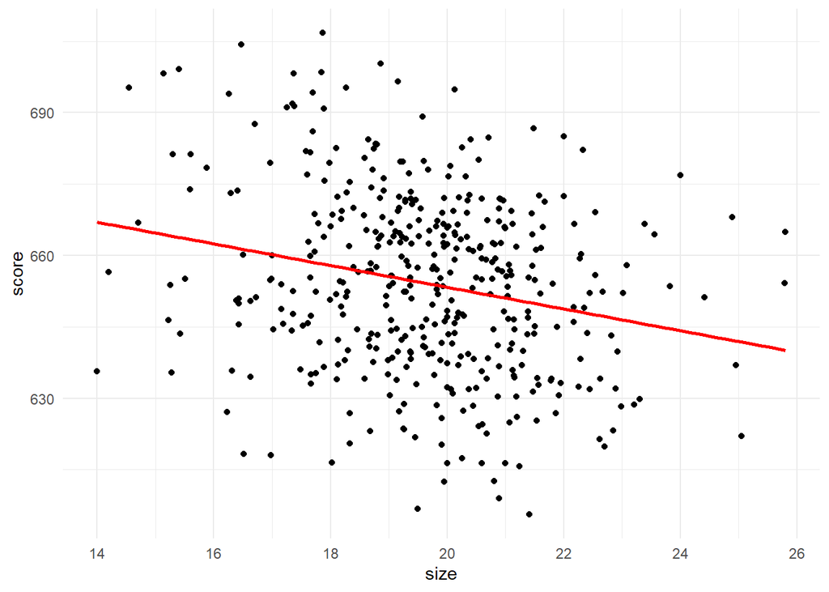

```r
ggplot(data_df, aes(x = size, score)) +
  geom_point() +
  geom_smooth(method = "lm", se = FALSE, color = "red") +
  theme_minimal()
```

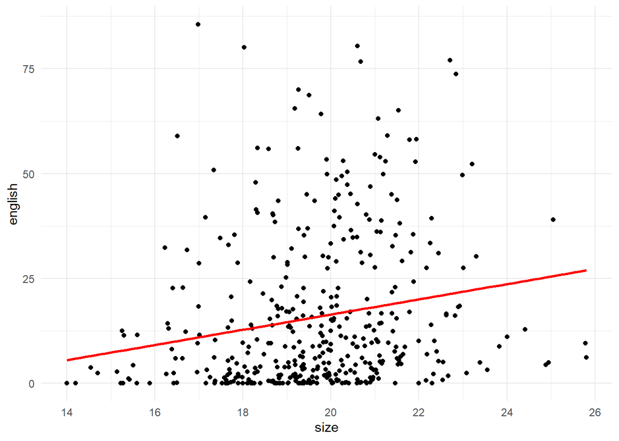

```r
ggplot(data_df, aes(x = size, english)) +
  geom_point() +
  geom_smooth(method = "lm", se = FALSE, color = "red") +
  theme_minimal()
```

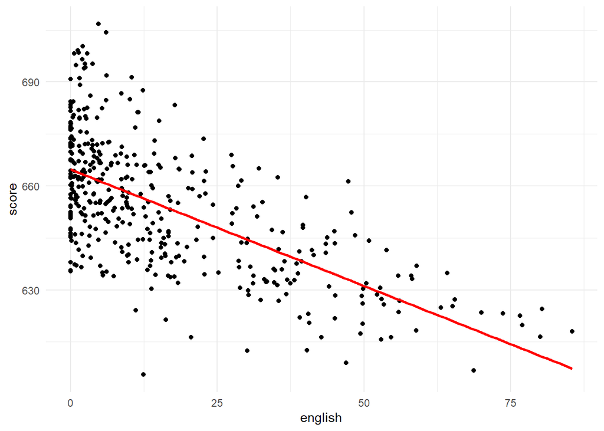

```r
ggplot(data_df, aes(x = english, score)) +
  geom_point() +
  geom_smooth(method = "lm", se = FALSE, color = "red") +
  theme_minimal()
```

Let’s create a correlation matrix using the given sample:

```r
cor(data_df)
```

```
##            english       size      score
## english  1.0000000  0.1876424 -0.6441238
## size     0.1876424  1.0000000 -0.2263627
## score   -0.6441238 -0.2263627  1.0000000
```

What story is the above correlation matrix telling us?

- Larger class sizes are associated with lower SAT scores
- Larger class sizes are associated with a greater share of English learners
- A greater share of English learners is associated with lower SAT scores

So, if we were to estimate below simple regression of `score` on `size`, is our $\beta_1$ estimate likely to be biased or unbiased? Why?

$$\text{score} = \beta_0 + \beta_1
\text{class size} + \varepsilon$$

From the data plots and correlation matrix we know that class size is positive correlated with the share of English learners in the class, which in turn is negatively correlated with the average class score.

Therefore, it is likely the case that our $\beta_1$ estimate will have **negative bias!**

What if we instead regress `score` on both `class size` and `english` by estimating the below model?

$$\text{score} = \beta_0 + \beta_1
\text{class size} + \beta_2 \text{english} + \varepsilon$$

We are now controlling for the effect of `english` on `score`, which rids our $\beta_1$ estimate of omitted variable bias.

Now let’s actually carry out the above analysis and see what we get:

```r
# Estimate both models
mod_simple <- lm(formula = score ~ size, data = data_df)
mod_multi  <- lm(formula = score ~ size + english, data = data_df)

# Create and print regression table
reg_table <- modelsummary(list(mod_simple, mod_multi))
reg_table
```

|  | Model 1 | Model 2 |
| --- | --- | --- |
| (Intercept) | 698.933 | 686.032 |
|  | (9.467) | (7.411) |
| size | -2.280 | -1.101 |
|  | (0.480) | (0.380) |
| english |  | -0.650 |
|  |  | (0.039) |
| Num.Obs. | 420 | 420 |
| R2 | 0.051 | 0.426 |
| R2 Adj. | 0.049 | 0.424 |
| AIC | 3650.5 | 3441.1 |
| BIC | 3662.6 | 3457.3 |
| Log.Lik. | -1822.250 | -1716.561 |
| F | 22.575 | 155.014 |
| RMSE | 18.58 | 14.46 |

- Do these results confirm our initial suspicions?
- What can we say about model fit?